# Warm-Up 01: Markdown Syntax

Cindy Lo

9/4/2018

## Game of Thrones

#### Daenerys Targaryen

> I spent my life in foreign lands. So many men have tried to kill me, I don’t remember all their names. I have been sold like a broodmare. I’ve been chained and betrayed, raped and defiled. Do you know what kept me standing through all those years in exile? Faith. Not in any gods. Not in myths and legends. In myself. In Daenerys Targaryen. The world hadn’t seen a dragon in centuries until my children were born. The Dothraki hadn’t crossed the sea. Any sea. They did for me. I was born to rule the Seven Kingdoms, and I will.

[figure not shown]

| Character Information |  |
| --- | --- |
| Status | Alive |
| Age | 22 in Season 7 |
| Date of Birth | Summer of 282 AC |
| Origin | Dragonstone (birthplace), Free Cities (raised) |
| Allegience | House Targaryen |
| Predecessor | Stannis Baratheon |
| Culture | Valaryian |
| Father | Aerys II Targaryen |
| Mother | Rhaella Targaryen |

## Cooking Recipe

### Corn Fritters

#### Ingredients

- 6 ears of corn (about 3 cups of corn)
- 4 scallions, both white and greens finely chopped
- 1/2 cup chopped herbs of your choice (i.e. chives)
- about 1 cup (6 ounces) grated sharp cheddar
- 3/4 teaspoon kosher salt, season to taste
- freshly ground black pepper
- 4 large eggs
- 1 cup all-purpose flour, plus 2 more tablespoons, if needed
- olive or a neutral oil for frying

#### Kitchen Tools

- Knife
- Frying Pan

#### Steps:

1. Shuck corn and stand the first stalk in a large bowl. Use a sharp knife to cut the kernels from the corn into the bowl, then run the back of your knife up and down the stalk to release as much of the corn juice as possible into the bowl. Repeat with remaining ears. It’s okay if you get a little more or a little less than 3 cups of corn.
2. Add scallions, herbs, cheese, and many grinds of black pepper and stir to evenly combine. Taste for seasoning.
3. Add the eggs and use a fork or spoon to stir until they’re all broken up and evenly coat the corn mixture.
4. Add 1 cup of flour and stir to throughly coat. (Mixture should resemble egg salad! A scoop of the mixture should hold its shape unless pressed down; if yours does not, add the remaining flour.)
5. Heat 2 to 3 tablespoons oil in a large frying pan over medium heat. Once hot and shimmering, add your first scoop of corn fritter batter and press it gently to flatten it.  
   Corn fritters cook quickly so keep an eye on them. When the underside is a deep golden brown, flip and cook to the same color on the second side. Drain on a paper towel, sprinkling on more salt. When it’s cool enough to try, taste and adjust the seasonings of the remaining batter if needed.
6. Cook remaining fritters in the same manner, adding more oil as needed.

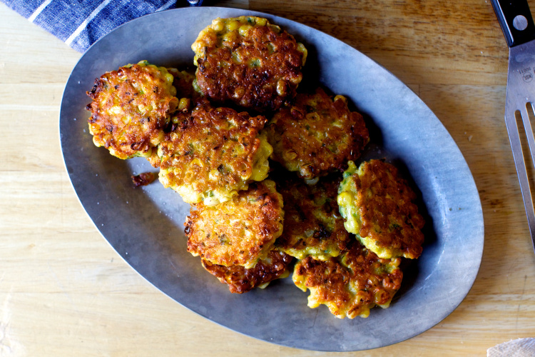

#### Additional Notes

You can eat this at any time of the year, but corn season usually starts in October and finishes by the end of November!

#### Have some fun with these variations:

- **Street corn-ish**: Work some lime zest into the batter, use cotija cheese intead of cheddar, keep the scallions, and use cilantro for the herb. Finish with a shake of chili powder or, even better, tajín, and sour cream or the sauce we dollop on here.
- **Miso-scallion with sriracha mayo**: Whisk 2 to 3 teaspoons white miso into the egg in the batter, skip the cheese, double-down on the scallions. Make sriracha mayo to taste, just the amount of each that tastes in good balance to you.
- **Cacio e pepe**: Replace scallions with parsley for the herb and add many many grinds of black pepper and sharp pecorino for the cheese.
- **Spiced**: Try this with 1/4 cup minced red onion instead of scallions, cilantro instead of chives, and then add 1 teaspoon each ground coriander and cumin, 1/4 teaspoon ground turmeric and cayenne or another red chili powder to taste. Finish with a cooling dollop of yogurt.

## Quadratic Equation

### Quadratic Formula

In algebra, a quadratic equation is any equation with the form
$$ax^{2} + bx + c = 0$$
where *x* represents an unknown, and *a*, *b*, and *c* are coefficients and represent known numbers such that a is not equal to 0. If a = 0, the equation is linear, not quadratic. The numbers *a*, *b*, and *c* are the coefficients of the equation, and may be distinguished by calling them, respectively, the *quadratic coefficient*, the *linear coefficient* and the *constant* or *free term*.

The formula for the roots of the general quadratic equation:
$$x = \frac{-b \pm \sqrt{b^{2} - 4ac}}{2a}$$
The derivation of the solution:
$$ax^{2} + bx + c = 0$$
$$4a^{2}x^{2} + 4abx + 4ac = 0$$
$$4a^{2}x^{2} + 4abx = -4ac$$
$$4a^{2}x^{2} + 4abx + b^{2} = b^{2} - 4ac$$
$$(2ax + b)^{2} = b^{2} - 4ac$$
$$2ax + b = \pm \sqrt{b^{2} - 4ac}$$
$$2ax = -b \pm \sqrt{b^{2} - 4ac}$$
$$x = \frac{-b \pm \sqrt{b^{2} - 4ac}}{2a}$$

## Comments and Reflections

#### What things were hard, even though you saw them in class?

In class, we went over a lot of data types, vectors, atomicity, coercion rules, recycling and indexing. I think remembering to add certain syntax (like $ or ` or the number of tabs) was especially difficult, as well as formatting my code in an organized appearance.

#### What was easy(-ish) even though we haven’t done it in class?

Writing LaTex equations was easy(-ish), although I kept forgetting to end each line with the double `$$`

#### Was this the first time you were using markdown? If yes, how do you feel about it?

Aside from Lab 01, this was the 2nd time I used markdown. I feel a little nervous, because it feels like an overwhelming amount of syntax to remember. Everything feels very new and unfamiliar to me.

#### Did you need help to complete the assignment? If so, what kind of help? Who helped you?

I did need help to complete the assignment, but I googled what I didn’t understand and the Markdown and LaTeX tutorials provided helped a lot to understand the material more.

#### How much time did it take to complete this HW?

2 hrs

#### What was the most time consuming part?

I forgot I could copy and paste the text for the recipe portion and typed most of the text in manually. Double-checking the formula was also very time-consuming.